# Rough-Work

Eliott Van Dieren

2023-03-19

## Renaming and factoring data thanks to histogram

```
##
##     1     2     3     4     5     6 other     8    10    13
##  2276  7558    95   698   446   166    62   121   157    51
```

Above, we created two dataset, one factoring and merging low categorical values (ex. browser etc). We also created a numerical dataset for histogram plotting where the visitor_type became 1,2,3 being New_Visitor, Other and Returning_Visitor

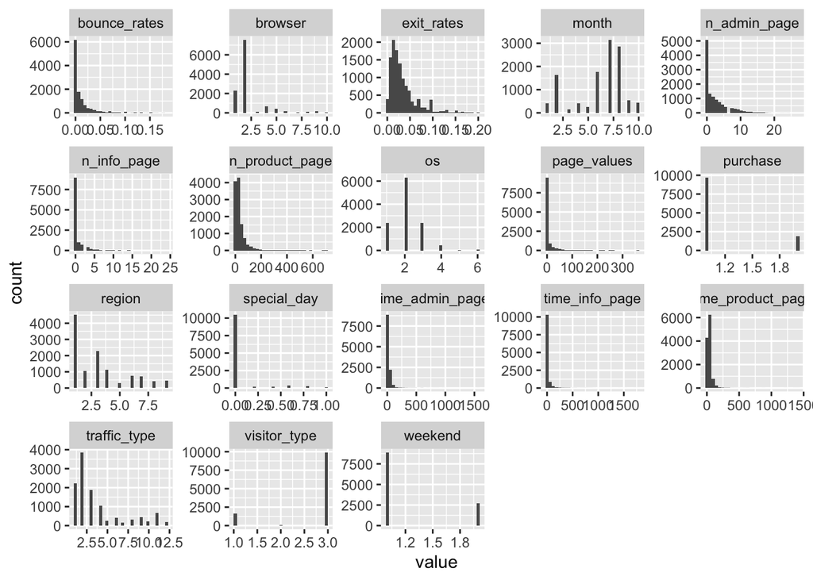

```r
#par(mfrow=c(2,n_cols/2 + n_cols%%2))
#for(i in 1:n_cols){
#  hist(as.numeric(Data[,i]),
#                  main = paste("Histogram of", names(Data)[i]))
#}

# Histogram plotting
par(mfrow=c(2,9))
Data_f %>% mutate_if(is.factor,as.numeric) %>% pivot_longer(everything()) %>% ggplot(aes(value)) +
  facet_wrap(~ name, scales = "free") + geom_histogram()
```

```r
gm0 <- glm(purchase~., data=Data_f,family = "binomial")
Anova(gm0,type=2,test="LR")
```

```
## Analysis of Deviance Table (Type II tests)
##
## Response: purchase
##                   LR Chisq Df Pr(>Chisq)
## n_admin_page          0.00  1    0.96604
## time_admin_page       0.92  1    0.33664
## n_info_page           2.51  1    0.11344
## time_info_page        0.17  1    0.68011
## n_product_page       39.15  1  3.927e-10 ***
## time_product_page     2.99  1    0.08396 .
## bounce_rates          0.60  1    0.43921
## exit_rates           43.08  1  5.246e-11 ***
## page_values        2042.19  1  < 2.2e-16 ***
## special_day           0.13  1    0.71828
## month               212.54  9  < 2.2e-16 ***
## os                    6.55  5    0.25595
## browser               9.08  9    0.43018
## region                7.23  8    0.51236
## traffic_type         41.08 11  2.335e-05 ***
## visitor_type          5.83  2    0.05415 .
## weekend               1.51  1    0.21859
## ---
## Signif. codes:  0 '***' 0.001 '**' 0.01 '*' 0.05 '.' 0.1 ' ' 1
```

```r
cat(AUC_eval(gm0,Data_f))
```

```
## 0.8844597
```

```r
#gm_t <- glm(purchase~.*weekend, data=Data_f,family = "binomial")
#Anova(gm_t,type=2,test="LR")
```

## Contingency tables for factor covariate

```r
table(Data_f$purchase, Data_f$visitor_type)
```

```
##
##         New_Visitor Other Returning_Visitor
##   FALSE        1244    53              8428
##   TRUE          422    16              1467
```

With those 2-way tables cross classifying the outcome depending on the type of visitor, we observe that there is 25% of buying when new visitors, and 15% for returning visitors, but there is much more volume for the returning visitors than the new visitors. Without doing a formal test, those percentages seem already different.

```r
table(Data_f$purchase, Data_f$month)
```

```
##
##          Aug  Dec  Feb  Jul June  Mar  May  Nov  Oct  Sep
##   FALSE  345 1411  147  345  233 1583 2786 2091  428  356
##   TRUE    76  216    3   66   29  192  365  758  114   86
```

```r
table(Data_f$purchase, Data_f$month)
```

```
##
##          Aug  Dec  Feb  Jul June  Mar  May  Nov  Oct  Sep
##   FALSE  345 1411  147  345  233 1583 2786 2091  428  356
##   TRUE    76  216    3   66   29  192  365  758  114   86
```

```r
only_sig_model <- glm(purchase ~ n_product_page+time_product_page+exit_rates+page_values+month+traffic_type+visitor_type,data=Data_f,family="binomial")
#week_end <- glm(purchase ~ time_product_page+exit_rates+page_values+month+traffic_type+visitor_type + weekend,data=Data_f,family="binomial")


#anova(gm0,only_sig_model,test="LRT")

AUC_eval(only_sig_model,Data_f) # better :)
```

```
## [1] 0.8878329
```

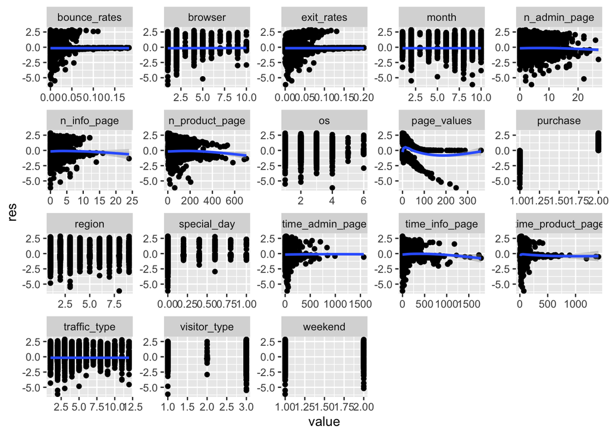

```r
# library(flexmix)
# BIC(only_sig_model) better bic than the gm0
# BIC(gm0)
# +visitor_type:weekend+I(page_values^2) + I(time_product_page^2
# Anova(only_sig_model,type=2,test="LR") all relevant (normal)
Data_f %>% mutate_if(is.factor,as.numeric) %>%
  mutate(res=resid(only_sig_model)) %>%
  pivot_longer(-res) %>% ggplot(aes(y=res,x=value)) +
  facet_wrap(~ name, scales = "free") + geom_point() + geom_smooth()
```

We can see a quadratic relation between page_values and a split there too. Let’s create an enhanced model from the residual plots

```r
enhanced <- glm(purchase ~ n_product_page+time_product_page+exit_rates+page_values+month+traffic_type+visitor_type + I(page_values^2) + I(page_values^3),data=Data_f,family="binomial")
Anova(enhanced,type=2,test="LR") # checking for relevancy
```

```
## Analysis of Deviance Table (Type II tests)
##
## Response: purchase
##                   LR Chisq Df Pr(>Chisq)
## n_product_page          55  1  1.536e-13 ***
## time_product_page        1  1  0.2234091
## exit_rates              51  1  1.185e-12 ***
## page_values         187010  1  < 2.2e-16 ***
## month                  237  9  < 2.2e-16 ***
## traffic_type            44 11  7.608e-06 ***
## visitor_type            15  2  0.0004706 ***
## I(page_values^2)       543  1  < 2.2e-16 ***
## I(page_values^3)       382  1  < 2.2e-16 ***
## ---
## Signif. codes:  0 '***' 0.001 '**' 0.01 '*' 0.05 '.' 0.1 ' ' 1
```

```r
#anova(only_sig_model,enhanced,test="LRT") # so really better
AUC_eval(enhanced,Data_f)
```

```
## [1] 0.9045673
```

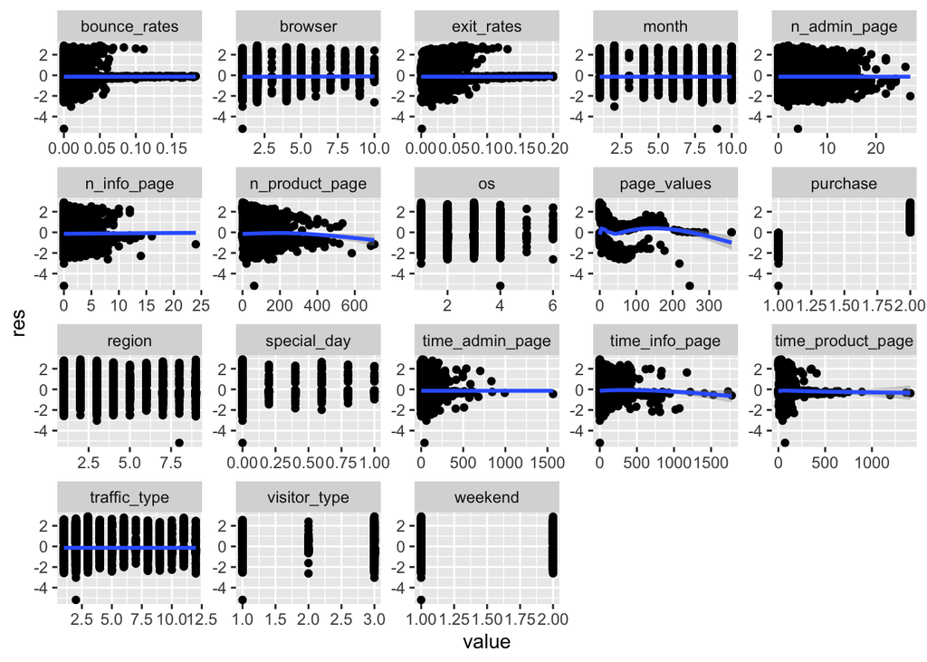

```r
Data_f %>% mutate_if(is.factor,as.numeric) %>%
  mutate(res=resid(enhanced)) %>%
  pivot_longer(-res) %>% ggplot(aes(y=res,x=value)) +
  facet_wrap(~ name, scales = "free") + geom_point() + geom_smooth()
```

Now, it is time to check for interactions

```r
table(Data_f$weekend, Data_f$visitor_type)
```

```
##
##         New_Visitor Other Returning_Visitor
##   FALSE        1192    64              7631
##   TRUE          474     5              2264
```

Checking visitors on the week-end vs during the work week gives us different percentages, might be interesting as interaction and finding new clusters of customers.

```r
enhanced_wk_vist <- glm(purchase ~ n_product_page+time_product_page+exit_rates+page_values+month+traffic_type+visitor_type + I(page_values^2) + I(page_values^3) + weekend:visitor_type,data=Data_f,family="binomial")

Anova(enhanced_wk_vist,type=2,test="LR")
```

```
## Analysis of Deviance Table (Type II tests)
##
## Response: purchase
##                      LR Chisq Df Pr(>Chisq)
## n_product_page             55  1  1.487e-13 ***
## time_product_page           2  1  0.2022476
## exit_rates                 49  1  2.512e-12 ***
## page_values            156671  1  < 2.2e-16 ***
## month                     234  9  < 2.2e-16 ***
## traffic_type               42 11  1.440e-05 ***
## visitor_type               15  2  0.0004706 ***
## I(page_values^2)          545  1  < 2.2e-16 ***
## I(page_values^3)          383  1  < 2.2e-16 ***
## visitor_type:weekend       10  3  0.0205703 *
## ---
## Signif. codes:  0 '***' 0.001 '**' 0.01 '*' 0.05 '.' 0.1 ' ' 1
```

```r
AUC_eval(enhanced_wk_vist,Data_f)
```

```
## [1] 0.9046418
```

```r
AUC_eval(enhanced,Data_f)
```

```
## [1] 0.9045673
```

See the final report for the models and final calculations `